# Math Concepts 2

## Functions

- A relation between a set of inputs and a set of possible outputs.
- Each input is related to exactly one output.
- Denoted as $f(x)$ where $x$ is the input.
- Sometimes instead of $f(x)$ we say $y$, so $y = f(x)$.
- Functions can represent real-world scenarios, e.g., growth over time.

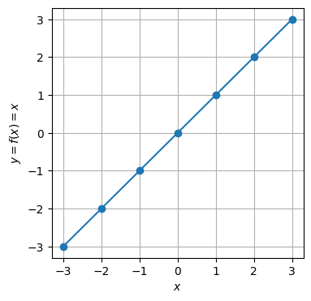

```python
# Linear f(x) = x
x = np.arange(-3, 4, 1)
y = x
plt.figure(figsize=(4, 4))
plt.plot(x, y, marker='o')
plt.xlabel('$x$')
plt.ylabel('$y = f(x) = x$')
plt.grid()
plt.show()
```

## Number $e$

- $e$ is an irrational number approximately equal to 2.71828.
- Arises naturally in various ways, particularly in situations where growth is involved.
- Nice feature (advanced): the function $f(x) = e^x$ is its own derivative.

## Logarithm

- The logarithm of a number `a` is the exponent `x` to which another fixed number (the base) `b` must be raised to produce that number.
- $log_b (a) = x$ means $b^x = a$
- Opposite of exponential.
- The logarithm to the base $e$ is called the natural logarithm ($ln$ or, sometimes, $log$ without specifying base).
- **Examples**:
  - $log_2 (8) = 3$ because $2^3 = 2 \times 2 \times 2 = 8$
  - $log_{10} (100) = 2$ because $10^2 = 10 \times 10 = 100$
  - $ln(5) = log_e(5) \approx 1.61$ because $e^{1.61} \approx 5$

# Typical ML Functions

- Functions that can approximate data distributions (typical in statistics):
  - Normal
  - Exponential
  - Long tailed
  - Logarithmic
- Functions used in data transformations or metrics:
  - Logarithmic
  - Quadratic
- Functions used in ML modeling:
  - Linear
  - Sigmoid
  - ReLU

## Normal

- Symmetrical, bell-shaped probability curve.
- Central 68%-1σ, 95%-2σ, 99.7%-3σ.
- Example: population height or student grades.

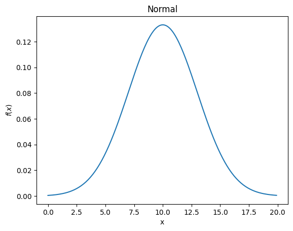

```python
# Plot normal distribution
x = np.arange(0, 20, 0.1)
plot_normal(x, mean=10, std=3)
plt.show()
```

## Exponential and Logarithmic Functions

- **Exponential**: Increases rapidly.
  - Example: Compound interest or radioactive decay.
- **Logarithmic**: Opposite of exponential.
  - Example: pH scale in chemistry or happiness-income.

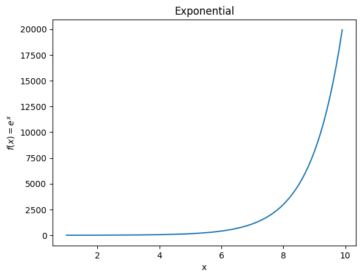

```python
# Plot exponential function
x = np.arange(1, 10, 0.1)
plot_exp(x)
plt.show()
```

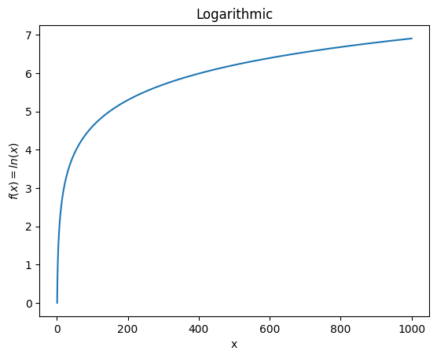

```python
# Plot logarithmic function
x = np.arange(1, 1000, 0.1)
plot_ln(x)
plt.show()
```

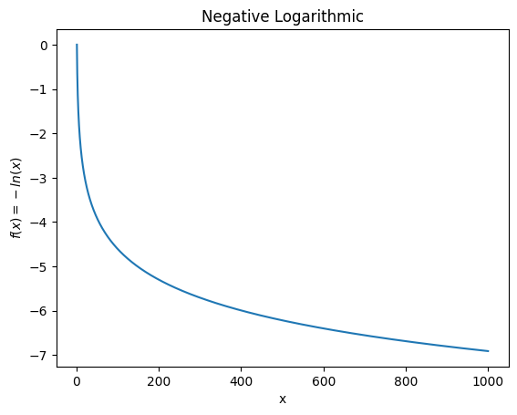

```python
# Plot negative logarithmic function
x = np.arange(1, 1000, 0.1)
y = -np.log(x)

plt.plot(x, y)
plt.title(r'Negative Logarithmic')
plt.xlabel('x')
plt.ylabel(r'$f(x) = -ln(x)$')
plt.show()
```

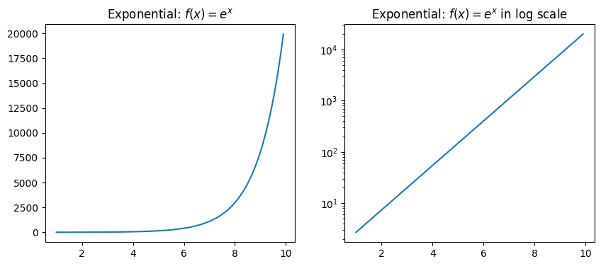

```python
# e^x standard and in log scale

x = np.arange(1, 10, 0.1)
plot_exp_log(x)
plt.show()
```

## Long Tail

- A large number of occurrences are far from the "head" and close to the "tail".
- Examples:
  - Book/music selling authors.
  - Task distribution in a supercomputer.

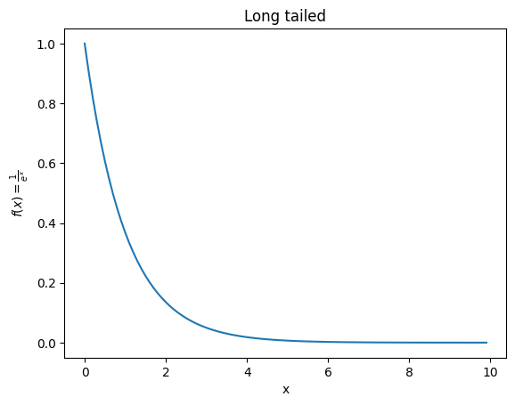

```python
# Long tailed distribution
x = np.arange(0, 10, 0.1)
plot_long_tail(x)
plt.show()
```

## Linear

- A straight line on a coordinate plane.
- $f(x)=mx+b$, where:
  - $m$ is the slope of the line.
  - $b$ is the y-intercept, where the line crosses the y-axis.

If $m = 1$ and $b = 0$, then $y = x$:

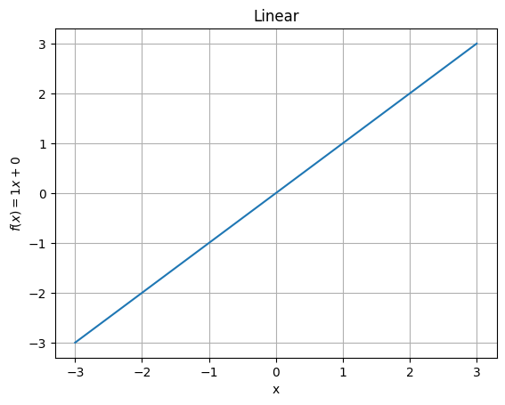

```python
# Linear function
x = np.arange(-3, 4, 1)
plot_linear(x, m=1, b=0)
plt.grid()
plt.show()
```

### Slope

Slope indicates for every unit of $x$, how much do we move on $y$?

- Positive slope: line goes up as you move right.
- Negative slope: line goes down as you move right.
- Zero slope: horizontal line.

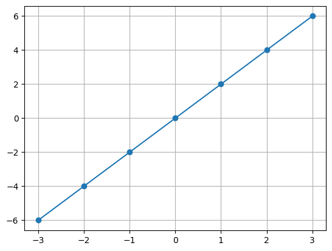

```python
# Linear 2x
x = np.arange(-3, 4, 1)
plt.plot(x, 2 * x, marker='o')
plt.grid()
plt.show()
```

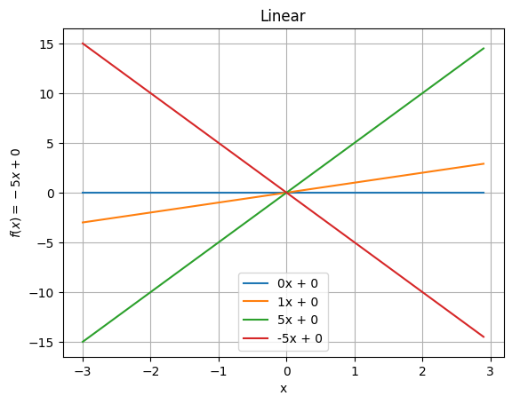

```python
# Linear functions setting intercept to 0
x = np.arange(-3, 3, 0.1)
plot_linear(x, m=0, b=0)
plot_linear(x, m=1, b=0)
plot_linear(x, m=5, b=0)
plot_linear(x, m=-5, b=0)
plt.grid()
plt.legend()
plt.show()
```

### Intercept

Where the line crosses de y-axis.

- Positive intercept: line goes up.
- Negative intercept: line goes down.
- Zero intercept: line crosses $(0, 0)$.

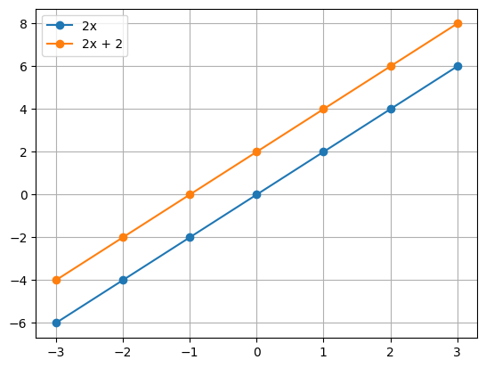

```python
# Linear 2x + 2 (crosses (0, 2))
x = np.arange(-3, 4, 1)
plt.plot(x, 2 * x, marker='o', label='2x')
plt.plot(x, 2 * x + 2, marker='o', label='2x + 2')
plt.grid()
plt.legend()
plt.show()
```

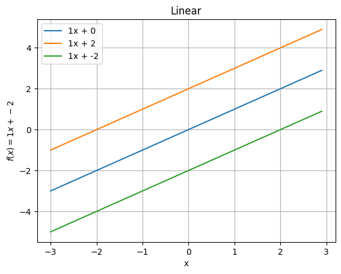

```python
# Linear functions setting slope to 1
x = np.arange(-3, 3, 0.1)
plot_linear(x, m=1, b=0)
plot_linear(x, m=1, b=2)
plot_linear(x, m=1, b=-2)
plt.legend()
plt.grid()
plt.show()
```

## Quadratic

- $f(x) = ax^2 + bx + c$.
  - $a$, $b$, $c$: Coefficients determining the shape and position.
- Parabola can open upwards (if $a>0$) or downwards (if $a<0$).

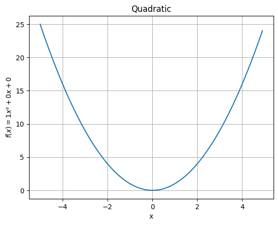

```python
# Quadratic function
x = np.arange(-5, 5, 0.1)
plot_quadratic(x, a=1, b=0, c=0)
plt.grid()
plt.show()
```

## Sigmoid

- S-shaped curve.
- $f(x) = \frac{1}{1 + e^{-x}}$
- $f(x)$ goes from 0 to 1 (not included).

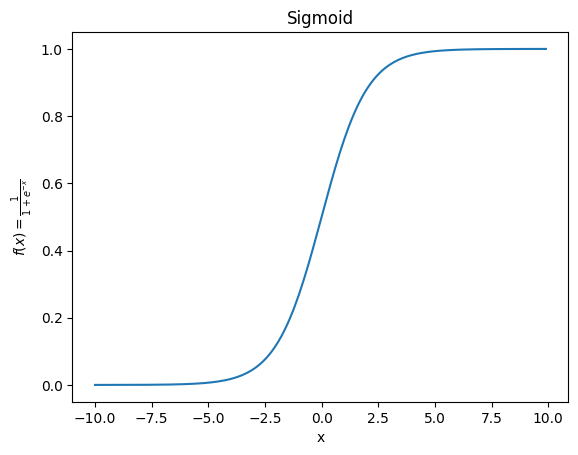

```python
# Sigmoid function
x = np.arange(-10, 10, 0.1)
plot_sigmoid(x)
plt.show()
```

## ReLU

- Widely used as activation function in neural networks.
- $f(x) = max(0, x)$

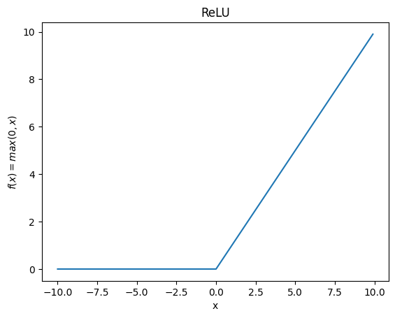

```python
# ReLU function
x = np.arange(-10, 10, 0.1)
plot_relu(x)
plt.show()
```